# BSG-MDS Practical 2 Statistical Genetics

### 7. Compute the inbreeding coefficient (f) for each SNP, and make a histogram of f. You can use function HWf for this purpose. Give descriptive statistics (mean, standard deviation, etc) of f calculated over the set of SNPs. What distribution do you expect f to follow theoretically? Use a probability plot to confirm your idea.

```r
ic<-HWf(polymorphic)
summary(ic)
```

```
##    Min. 1st Qu.  Median    Mean 3rd Qu.    Max.    NA's
##   -0.96   -0.06    0.01    0.02    0.08    0.98  122389
```

```r
print(paste0("The descriptive statistiucs are:"))
```

```
## [1] "The descriptive statistiucs are:"
```

```r
print(paste0("    - Mean: ",summary(ic)[4]))
```

```
## [1] "    - Mean: 0.0187182056859644"
```

```r
print(paste0("    - Standard deviation: ",sd(ic, na.rm = TRUE)))
```

```
## [1] "    - Standard deviation: 0.130155015109863"
```

```r
print(paste0("    - Min: ",summary(ic)[1]))
```

```
## [1] "    - Min: -0.962616822429907"
```

```r
print(paste0("    - Max: ",summary(ic)[6]))
```

```
## [1] "    - Max: 0.981249452378866"
```

```r
print(paste0("    - Number of NAs: ",summary(ic)[7]))
```

```
## [1] "    - Number of NAs: 122389"
```

```r
hist_data <- hist(ic, breaks = 30, col = "skyblue", xlab = "Inbreeding Coefficient (f)",
                  ylab = "Frequency", main = "Histogram of Inbreeding Coefficients", plot = FALSE)
breaks <- hist_data$breaks

hist(ic, breaks = breaks, col = "skyblue", xlab = "Inbreeding Coefficient (f)",
     ylab = "Frequency", main = "Histogram of Inbreeding Coefficients", ylim = c(0,20000))

print("The distribution we expect f to follow theoretically is a normal distribution")
```

```
## [1] "The distribution we expect f to follow theoretically is a normal distribution"
```

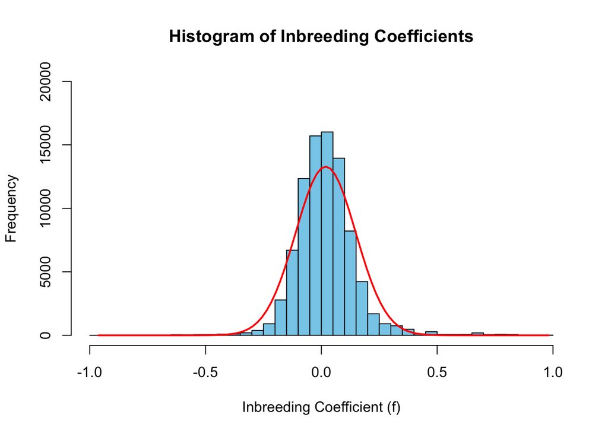

```r
# Fit a normal distribution curve to the histogram
mu <- mean(ic, na.rm = TRUE)
sigma <- sd(ic, na.rm = TRUE)
x <- seq(min(ic, na.rm = TRUE), max(ic, na.rm = TRUE), length.out = 100)
y <- dnorm(x, mean = mu, sd = sigma) * length(ic[is.finite(ic)]) * diff(breaks[1:2])
lines(x, y, col = "red", lwd = 2)
```

```r
print("The distribution we expect f to follow theoretically is a normal distribution")
```

```
## [1] "The distribution we expect f to follow theoretically is a normal distribution"
```

### 8. Apply the exact test for HWE to each SNP, using different significant levels. Report the number and percentage of significant variants using an exac test for HWE with alpha = 0.10, 0.05, 0.01 and 0.001. State your conclusions.

```r
hwe<-HWExactStats(polymorphic, x.linked = FALSE)
hwe_signSNP<-which(hwe<0.1)
print(paste0("The number of significant SNPs (alpha = 0.1) parcentage of significant SNPs (alpha = 0.1) are ", round((length(hwe_signSNP)*100)/length(hwe),1),"%"))
```

```
## [1] "The number of significant SNPs (alpha = 0.1) parcentage of significant SNPs (alpha = 0.1) are 4.4%"
```

```r
hwe_signSNP<-which(hwe<0.05)
print(paste0("The number of significant SNPs (alpha = 0.05) parcentage of significant SNPs (alpha = 0.05) are ", round((length(hwe_signSNP)*100)/length(hwe),1),"%"))
```

```
## [1] "The number of significant SNPs (alpha = 0.05) parcentage of significant SNPs (alpha = 0.05) are 2.5%"
```

```r
hwe_signSNP<-which(hwe<0.01)
print(paste0("The number of significant SNPs (alpha = 0.01) parcentage of significant SNPs (alpha = 0.01) are ", round((length(hwe_signSNP)*100)/length(hwe),1),"%"))
```

```
## [1] "The number of significant SNPs (alpha = 0.01) parcentage of significant SNPs (alpha = 0.01) are 1%"
```

```r
hwe_signSNP<-which(hwe<0.001)
print(paste0("The number of significant SNPs (alpha = 0.001) parcentage of significant SNPs (alpha = 0.001) are ", round((length(hwe_signSNP)*100)/length(hwe),1),"%"))
```

```
## [1] "The number of significant SNPs (alpha = 0.001) parcentage of significant SNPs (alpha = 0.001) are 0.6%"
```